# andrews

Sigbert Klinke

sigbert@hu-berlin.de

04 Februar, 2023

```r
library(andrews)
```

# General

The `andrews` routine, implemented by Jaroslav Myslivec, has been rewritten and extended. The old routine is still available as `andrews0` and the rewritten routine should give the same graphics with the same parameter values.

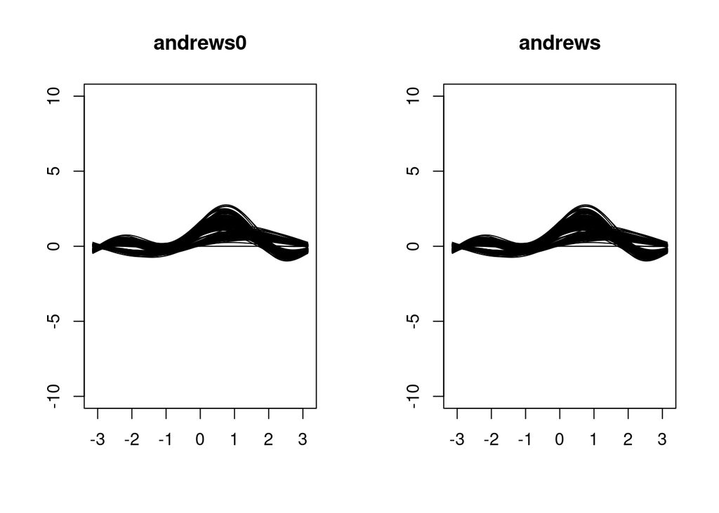

```r
op <- par(mfrow=c(1,2))
andrews0(iris, main="andrews0")
andrews(iris, main="andrews")
par(op)
```

Some more types of curves has been added. To see more comparisons of `andrews` and `andrews0`, run interactively

```r
zzz()
```

# Extensions

Full parameter list for `andrews` is:

```r
andrews (df, type = 1, clr = NULL, step = 100, ymax = 10,          # old parameters
         alpha = NULL, palcol = NULL, lwd = 1, lty = "solid", ...) # new parameters
```

The parameters in the call to `andrews` that come in `...` are passed to `plot` to draw the base window:

- The parameters `x`, and `y` cannot be set by the user through `...`.
- Available user parameters are `main`, `sub`, `xlim`, `ylim`, `xlab`, `ylab`, `axes`, `asp` and possibly other parameters.

Note that the setting of `ylim` has priority over the setting of `ymax`.

## Scaling the window height and width

The height of the window can be scaled by setting `ymax` or `ylim`.

1. If `ymax` is not set then `ylim=c(-10,10)` is used.
2. if `ymax` is set to `NA`, then `ylim=c(-lim,lim)`, where the maximum height `lim` is calculated from the curves. Note that this option doubles the calculation time.
3. by setting `ylim` directly.

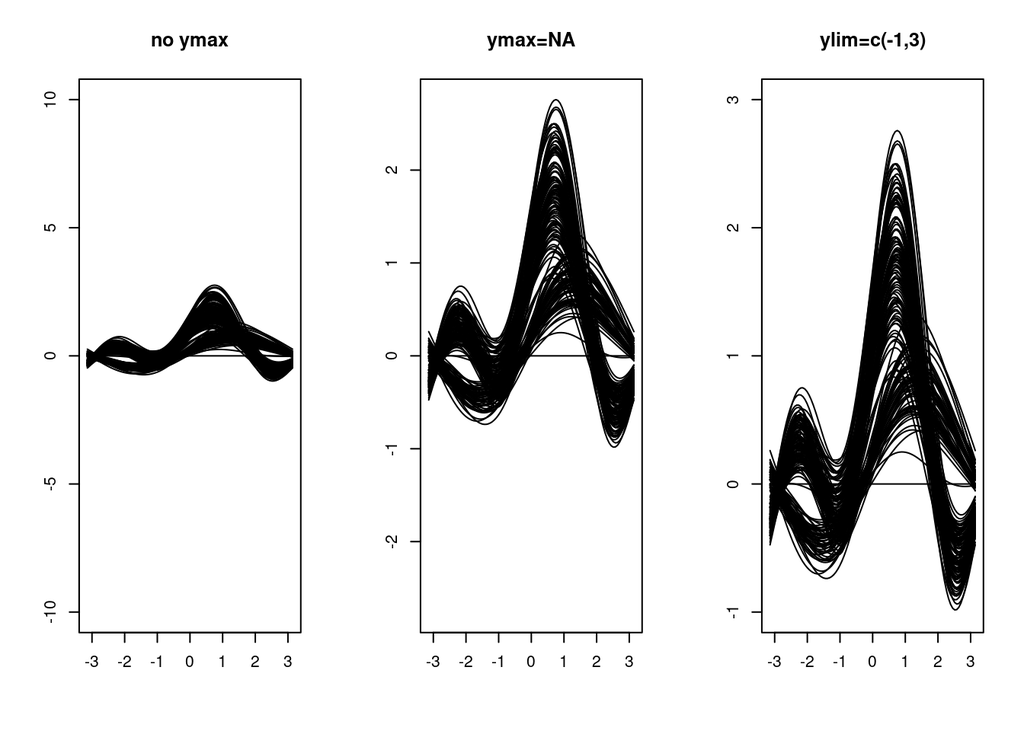

```r
op<-par(mfrow=c(1,3))
andrews(iris, main="no ymax")
andrews(iris, ymax=NA, main="ymax=NA")
andrews(iris, ylim=c(-1,3), main="ylim=c(-1,3)")
par(op)
```

The width of the window can be scaled by setting `xlim`, which is particularly useful for `type==3` or `type==5`.

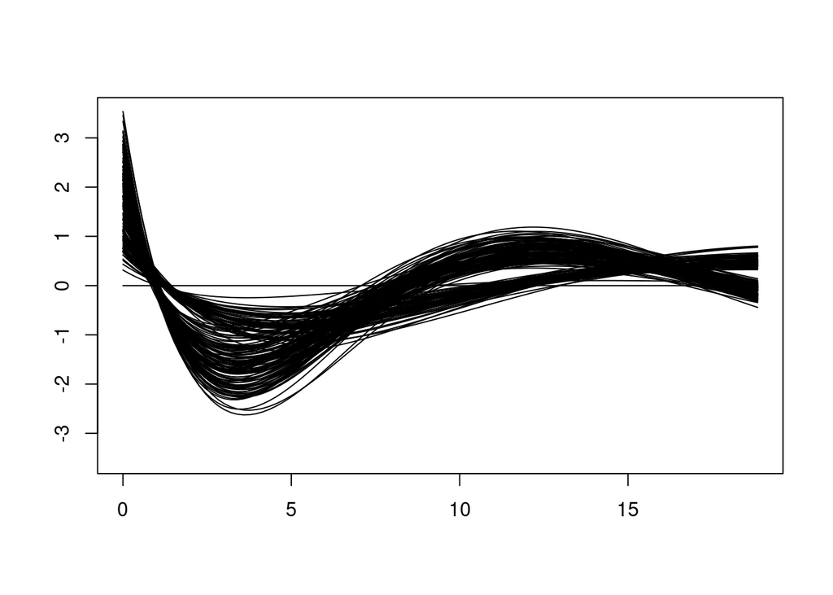

```r
andrews(iris, type=3, xlim=c(0,6*pi), ymax=NA)
```

## Line type and width

The parameters `lty` and `lwd` determine the linetype and width. The length of the parameters must be either `1` or `nrow(df)`. In the first case the values are applied to each curve, in the second case `lty[i]` and `lwd[i]` are used for the `i`th line.

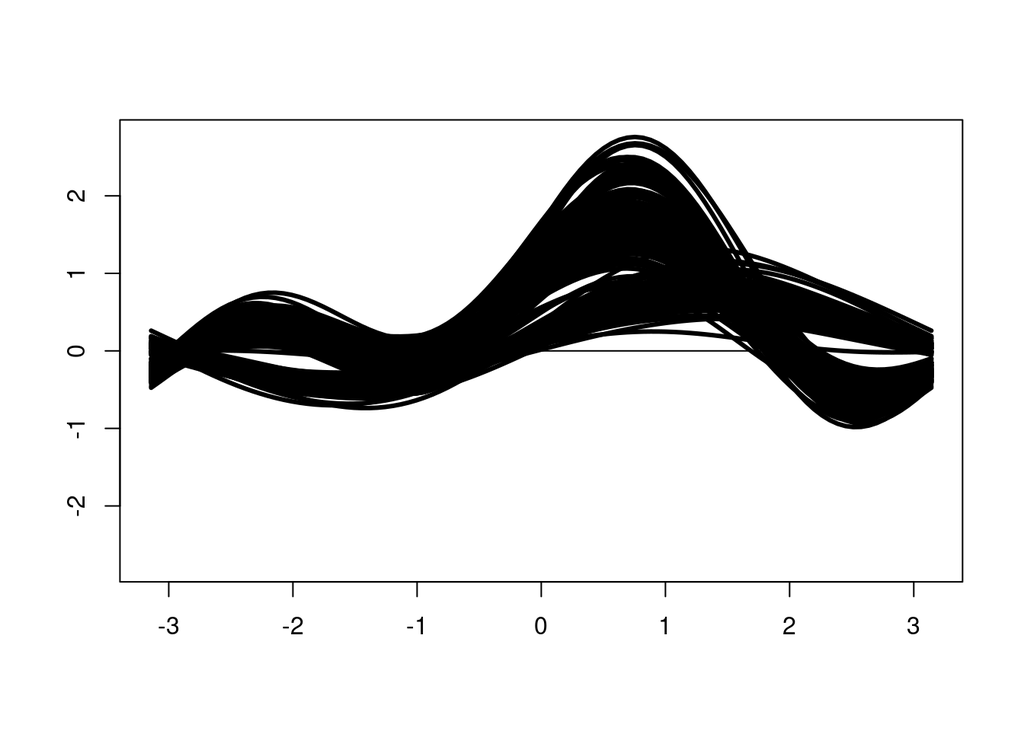

```r
andrews(iris, ymax=NA, lwd=3)
```

## Colouring the curves

The curves can be coloured individually if `length(clr)==nrow(df)`.

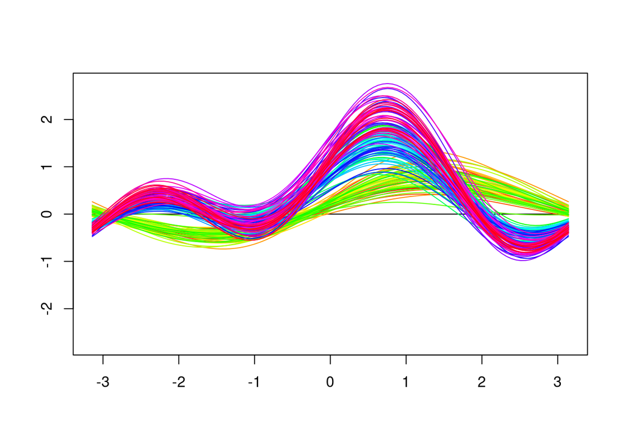

```r
andrews(iris, ymax=NA, clr=rainbow(nrow(iris)))
```

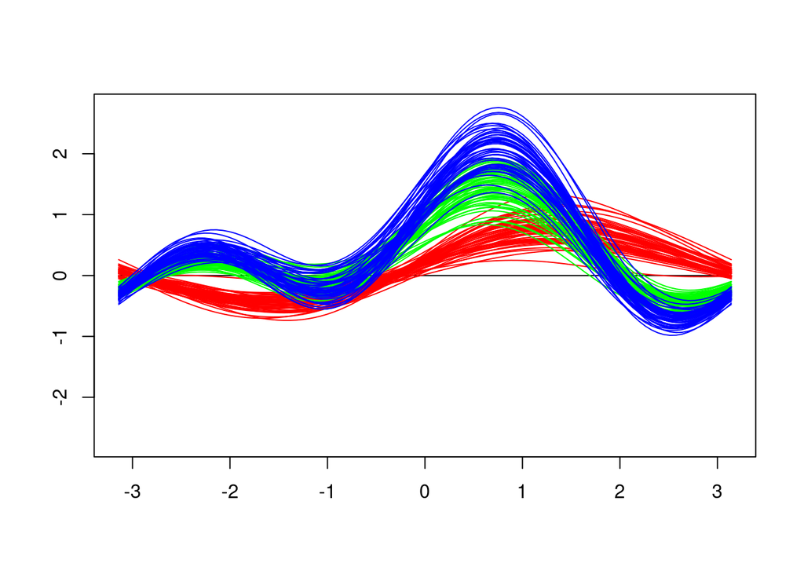

```r
andrews(iris, ymax=NA, clr=5) # iris$Species
```

If `is.numeric(df[,clr])` is `FALSE` then `rainbow(nuv)` is used for the colours, where `nuv` is the number of unique values (`nuv = length(unique(df[,clr])`). You can use `palcol` to select another palette that gives `nuv` colours.

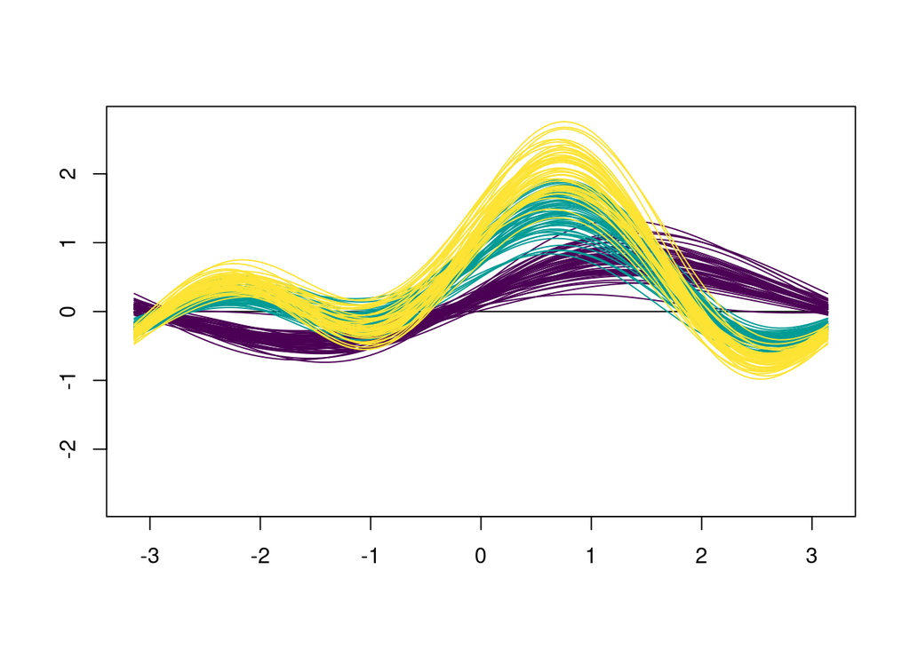

```r
andrews(iris, ymax=NA, clr=5, palcol=hcl.colors) # iris$Species
```

If `is.numeric(df[,clr])` is `TRUE`, the variable `color(df[,clr])` (scaled to the interval $[0, 1]$) is used. The default is `function(v) { hsv(1,1,v,1) }`, but any other colouring function can be used.

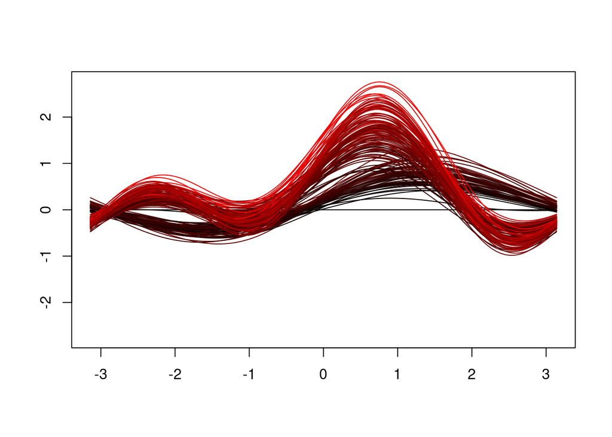

```r
andrews(iris, ymax=NA, clr=1) # iris$Sepal.Length
```

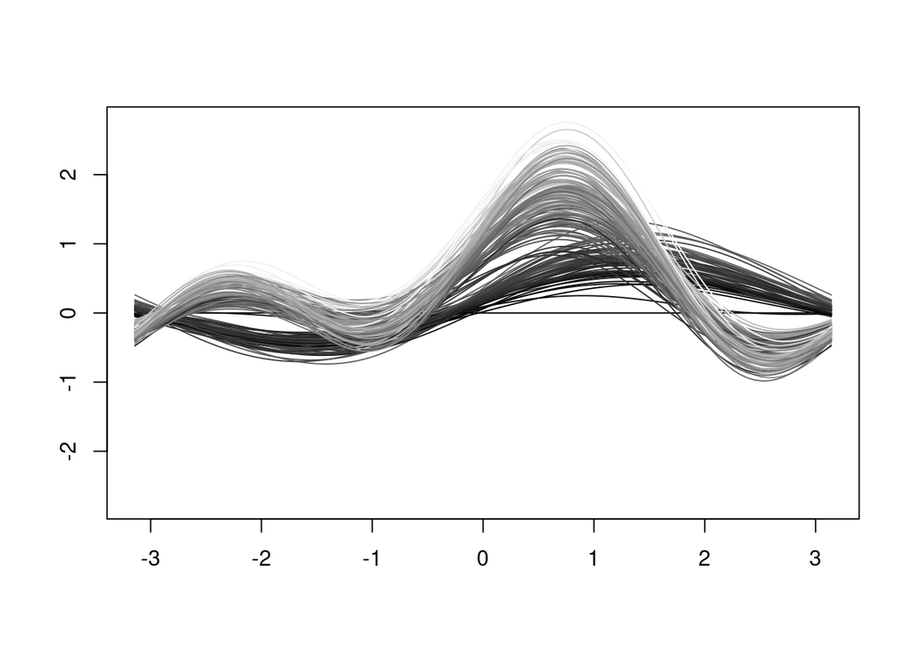

```r
andrews(iris, ymax=NA, clr=1, palcol=function(v) { gray(v) }) # iris$Sepal.Length
```

or alternatively

```r
andrews(iris, ymax=NA, clr=1, palcol=gray) # iris$Sepal.Length
```

## Alpha compositing/blending of curves

If you plot many curves then the curve details disappear by overplotting. If the output device supports the alpha channel, the parameter `alpha` ($0<\alpha<1$) is applied to all curves (`length(alpha)==1`) or one for each observation (`length(alpha)==nrow(df)`).

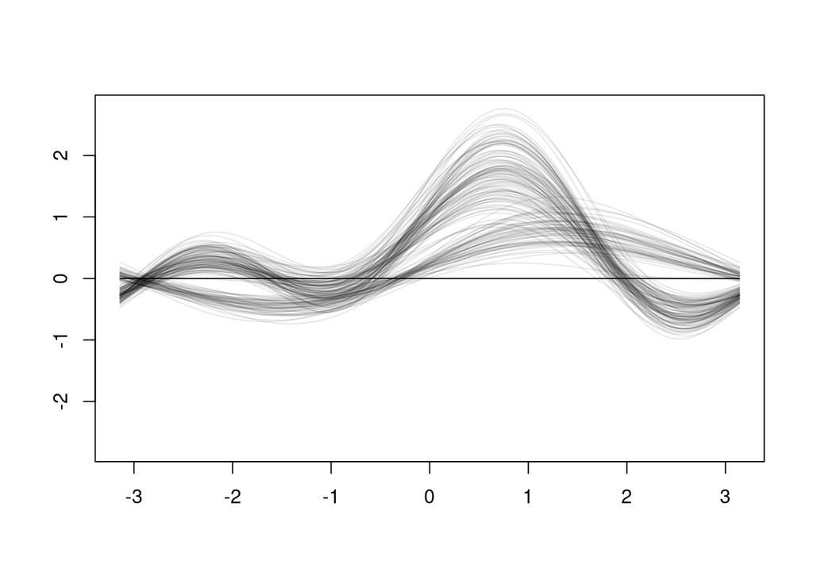

```r
andrews(iris, ymax=NA, alpha=0.1)
```

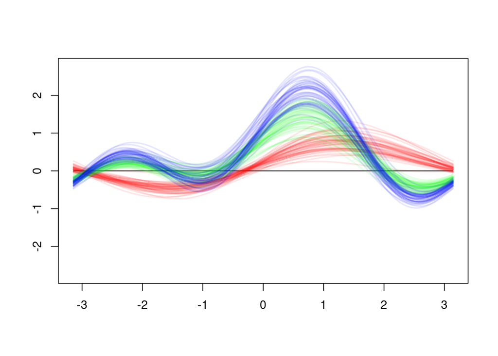

```r
andrews(iris, ymax=NA, clr=5, alpha=0.1, lwd=2)
```

## Curve types

All types of Andrews curves can be written as

$$f_i(t) = \sum_{k=1}^p x_{ik} g_k(t).$$

Currently, six types of curves are implemented, which are determined by the parameter `type`:

1. $f(t)=x_1/\sqrt{2}+x_2\sin(t)+x_3\cos(t)+x_4\sin(2t)+x_5\cos(2t)+...$
2. $f(t)=x_1\sin(t)+x_2\cos(t)+x_3\sin(2t)+x_4\cos(2t)+...$
3. $f(t)=x_1\cos(\sqrt{t})+x_2\cos(\sqrt{2t})+x_3\cos(\sqrt{3t})+...$
4. $f(t)=0.5^{p/2}x_1+0.5^{(p-1)/2} x_2(\sin(t)+\cos(t))+0.5^{(p-2)/2} x_3(\sin(t)-\cos(t))+0.5^{(p-3)/2} x_4(\sin(2t)+\cos(2t))+0.5^{(p-4)/2}x_5(\sin(2t)-\cos(2t))+...$ with $p$ the number of variables
5. $f(t)=x_1\cos(\sqrt{p_0} t)+x_2\cos(\sqrt{p_1}t)+x_3\cos(\sqrt{p_2}t)+...$ with $p_0=1$ and $p_i$ the i-th prime number
6. $f(t)=1/\sqrt{2}(x_1+x_2(\sin(t)+\cos(t))+x_3(\sin(t)-\cos(t))+x_4(\sin(2t)+\cos(2t))+x_5(\sin(2t)-\cos(2t))+...)$

With `deftype` the list of types can be queried by

```r
deftype(1)
```

```
#> $fun
#> function (n, t)
#> {
#>     n <- as.integer(if (n < 1) 1 else n)
#>     m <- matrix(1/sqrt(2), nrow = length(t), ncol = n)
#>     if (n > 1) {
#>         for (i in 2:n) {
#>             m[, i] <- if (i%%2)
#>                 cos((i%/%2) * t)
#>             else sin((i%/%2) * t)
#>         }
#>     }
#>     m
#> }
#> <bytecode: 0x55f9afbbe988>
#> <environment: 0x55f9afbca678>
#>
#> $range
#> [1] -3.141593  3.141593
```

A curve type consists of a function `function(n, t)` which computes a matrix of $(g_1(t), \ldots, g_n(t))$ and a default range for plotting, usually $-\pi$ till $\pi$.

A new curve type and a default plot range can be implemented by number or name:

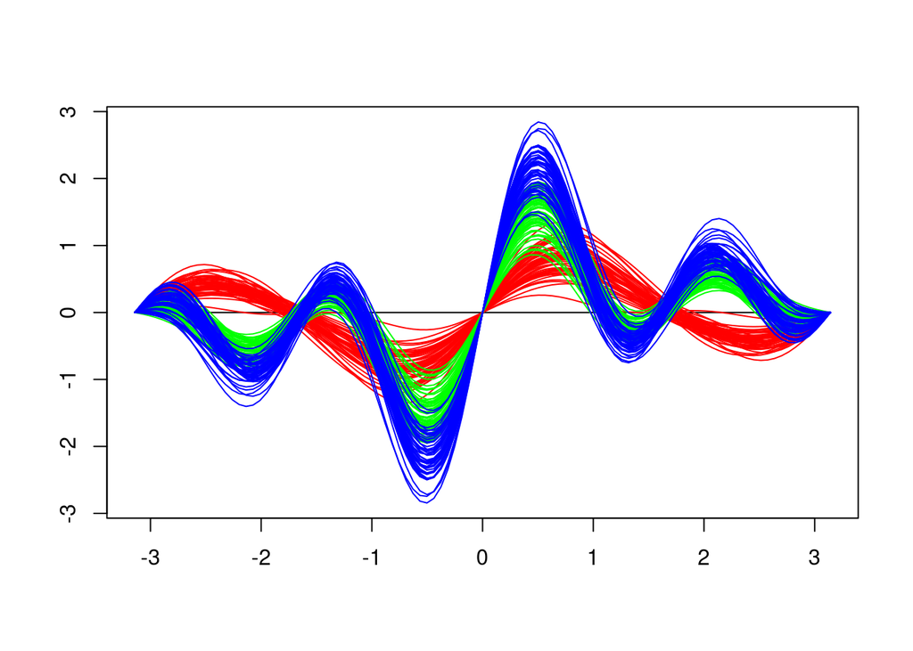

```r
deftype("sine", xlim = c(-pi, pi), function(n, t) {
  n <- as.integer(if (n<1) 1 else n)
  m <- matrix(NA, nrow=length(t), ncol=n)
  for (i in 1:n) m[,i] <- sin(i*t)
  m
})
andrews(iris, "sine", ymax=NA, clr=5)
```

# Some theoretical properties

The representation of a set of multivariate observations as curves was proposed by Andrews (1972). For a set of orthonormal basis functions $g_i(t)$ with $i=1, 2, 3, \ldots$ in an interval $[a, b]$ it holds:

$$\int_a^b g_i(t) g_j(t) dt = \delta_{ij}
= \begin{cases} 1 & \text{ if } i=j \\ 0 & \text{ if } i\neq j
\end{cases}$$

If one creates from multivariate observations $x_i=(x_{i1}, \ldots, x_{ip})$ with $i=1,2,\ldots,n$ a function

$$f_i(t) = \sum_{k=1}^p x_{ik} g_k(t)$$

then it follows:

**Property 1** - The integral of the squared difference of two curves is equal to the squared Euclidean distance between the data points $x_i$ and $x_j$:
$$\begin{align*}
\int_a^b (f_i(t)-f_j(t))^2 dt & = \int_a^b \left(\sum_{k=1}^p
(x_{ik}- x_{jk}) g_k(t)\right)^2 dt \\
&= \sum_{k=1}^p \sum_{l=1}^p (x_{ik}- x_{jk}) (x_{il}- x_{jl})
\underbrace{\int_a^b g_k(t)g_l(t) dt}_{= \delta_{kl}}\\
&= \sum_{k=1}^p (x_{ik}- x_{jk})^2
\end{align*}$$

This makes the Andrews curves useful for visualising multivariate outliers and clusters in the data.

None of the basis functions of the six types of Andrews curves form an orthonormal system, but two (`type %in% c(1,2)`) of them form an orthogonal system:

$$\int_{-\pi}^{\pi} g_i(t)g_j(t) dt =
\begin{cases} \pi & \text{ if } i=j \\ 0 & \text{ if } i\neq j
\end{cases}$$
Thus, property 1 changes to

$$\int_{-\pi}^{\pi} (f_i(t)-f_j(t))^2 dt
= \pi \sum_{k=1}^p (x_{ik}- x_{jk})^2$$

**Property 2** - The average curve is the mean value of the observations:

$$\begin{align*}
\bar{f}(t) &= \frac1n \sum_{i=1}^n f_i(t) =\frac1n \sum_{i=1}^n
\sum_{k=1}^p x_{ik} g_k(t)\\
&=\sum_{k=1}^p g_k(t) \left(\frac1n \sum_{i=1}^n x_{ik}\right)\\
&=\sum_{k=1}^p g_k(t) \bar{x}_k
\end{align*}$$

**Property 3** - For a given $t$, the variable $P_t=\sum_{k=1}^p X_k w_{kt}$ can be considered as a univariate projection of the variables $X_1$, $X_2$, …, $X_p$. If $Var(X_k)=\sigma$ and $Cov(X_k,X_l)=\delta_{kl}$ hold then

$$Var(P_t)= Var\left(\sum_{k=1}^p X_k
w_{kt}\right) = \sum_{k=1}^p w_{kt}^2 Var(X_k)$$
For the curves with `type %in% c(1,2,6)` $Var(P_t)\approx \sigma^2 p/2$ holds, since $\sin^2(t)+\cos^2(t)=1$. For these curves, however, we only cover a subset of the possible one-dimensional projections.

For `type %in% c(3,5)`, the choice of $\sqrt{p_i}$ ensures that all possible one-dimensional projections are used, but the range $[a,b]$ is not fixed. Usually $a=0$ is chosen and $b$ *“appropriate”* (in practice $b=4\pi$).

# References

- Andrews, D. F. (1972), Plots of High-dimensional Data, Biometrics, 28, 125–136.
- Gnanadesikan, R. (1997). Methods for Statistical Data Analysis of Multivariate Observations, 2nd Edition. Wiley, New York.
- Khattree, R., Naik, D. N. (2002) Andrews Plots for Multivariate Data: Some New Suggestions and Applications. Journal of Statistical Planning and Inference, 100(2), 411-425.